# Sales vs. Advertising

Maria Tackett

01.14.19

In this mini analysis, we will work with the `Advertising` data used in Chapters 2 and 3 of *Introduction to Statistical Learning*.

## Data and packages

We start with loading the packages we’ll use.

```r
library(readr)
library(tidyverse)
library(skimr)
library(broom)
```

```r
advertising <- read_csv("data/advertising.csv")
```

We will analyze the advertising and sales data for 200 markets. The variables we’ll use are

- `tv`: total spending on TV advertising (in $thousands)
- `radio`: total spending on radio advertising (in $thousands)
- `newspaper`: total spending on newspaper advertising (in $thousands)
- `sales`: total sales (in $millions)

## Analysis

We’ll begin the analysis by getting quick view of the data:

```r
glimpse(advertising)
```

```
## Observations: 200
## Variables: 4
## $ tv        <dbl> 230.1, 44.5, 17.2, 151.5, 180.8, 8.7, 57.5, 120.2, 8.6…
## $ radio     <dbl> 37.8, 39.3, 45.9, 41.3, 10.8, 48.9, 32.8, 19.6, 2.1, 2…
## $ newspaper <dbl> 69.2, 45.1, 69.3, 58.5, 58.4, 75.0, 23.5, 11.6, 1.0, 2…
## $ sales     <dbl> 22.1, 10.4, 9.3, 18.5, 12.9, 7.2, 11.8, 13.2, 4.8, 10.…
```

Next, we can calculate summary statistics for each of the variables in the data set.

```r
advertising %>% skim()
```

```
## Skim summary statistics
##  n obs: 200
##  n variables: 4
##
## ── Variable type:numeric ───────────────────────────────────────────────────────────────────────────────
##   variable missing complete   n   mean    sd  p0   p25    p50    p75  p100
##  newspaper       0      200 200  30.55 21.78 0.3 12.75  25.75  45.1  114
##      radio       0      200 200  23.26 14.85 0    9.97  22.9   36.52  49.6
##      sales       0      200 200  14.02  5.22 1.6 10.38  12.9   17.4   27
##         tv       0      200 200 147.04 85.85 0.7 74.38 149.75 218.82 296.4
##      hist
##  ▇▇▅▅▂▁▁▁
##  ▇▆▅▅▆▅▆▅
##  ▁▃▇▇▆▃▃▂
##  ▆▅▆▅▅▇▆▅
```

1. What type of advertising has the smallest median spending?
2. What type of advertising has the largest variation in spending?
3. Describe the shape of the distribution of `sales`.

We are most interested in understanding how advertising spending affect sales. One way to quantify the relationship between the variables is by calculating the correlation matrix.

```r
advertising %>%
  cor()
```

```
##                   tv      radio  newspaper     sales
## tv        1.00000000 0.05480866 0.05664787 0.7822244
## radio     0.05480866 1.00000000 0.35410375 0.5762226
## newspaper 0.05664787 0.35410375 1.00000000 0.2282990
## sales     0.78222442 0.57622257 0.22829903 1.0000000
```

1. What is the correlation between `radio` and `sales`? Interpret this value.
2. What type of advertising has the strongest linear relationship with `sales`?

Below are visualizations of `sales` versus each explanatory variable.

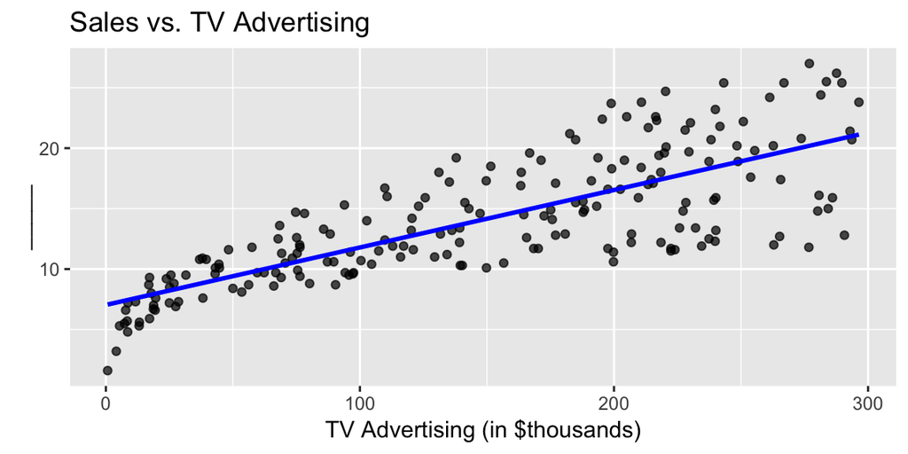

```r
advertising %>%
  ggplot(mapping = aes(x=tv,y=sales)) +
  geom_point(alpha=0.7) +
  geom_smooth(method="lm",se=FALSE,color="blue") +
  labs(title = "Sales vs. TV Advertising",
       x= "TV Advertising (in $thousands)",
       y="_____") #fill in the Y axis label
```

[figure not shown]

```r
advertising %>%
  ggplot(mapping = aes(x=radio,y=sales)) +
  geom_point(alpha=0.7) +
  geom_smooth(method="lm",se=FALSE,color="red") +
  labs(title = "Sales vs. TV Advertising",
       x= "Radio Advertising (in $thousands)",
       y="Sales (in $millions)")
```

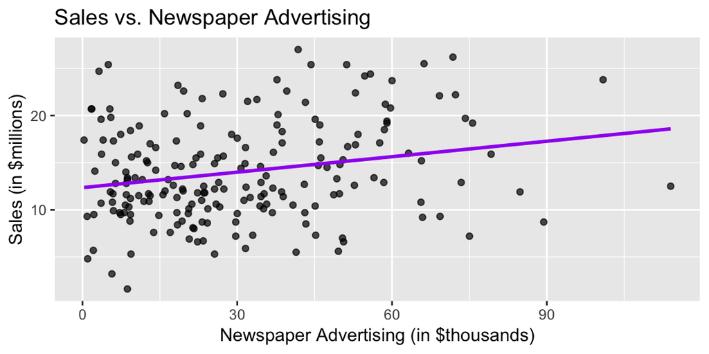

```r
advertising %>%
  ggplot(mapping = aes(x=newspaper,y=sales)) +
  geom_point(alpha=0.7) +
  geom_smooth(method="lm",se=FALSE,color="purple") +
  labs(title = "Sales vs. Newspaper Advertising",
       x= "Newspaper Advertising (in $thousands)",
       y="Sales (in $millions)")
```

Since `tv` appears to have the strongest linear relationship with `sales`, let’s calculate a simple linear regression model using these two variables.

```r
ad_model <- lm(sales ~ tv, data=advertising)
ad_model
```

```
##
## Call:
## lm(formula = sales ~ tv, data = advertising)
##
## Coefficients:
## (Intercept)           tv
##     7.03259      0.04754
```

1. Write the model equation.
2. Interpret the intercept in the context of the problem.
3. Interpret the slope in the context of the problem.